# Reproducible Research Project 2: Health and Economic Impacts of Extreme Weather in USA

Valentino Djaja Sastra

9/15/2021

## Executive Summary

Storms and other severe weather events can cause both public health and economic problems for communities and municipalities. Many severe events can result in fatalities, injuries, and property damage, and preventing such outcomes to the extent possible is a key concern.

This project involves exploring the U.S. National Oceanic and Atmospheric Administration’s (NOAA) storm database. This database tracks characteristics of major storms and weather events in the United States, including when and where they occur, as well as estimates of any fatalities, injuries, and property damage.

The main objectives of this project is to address following questions:

1. Across the United States, which types of events are most harmful with respect to population health?
2. Across the United States, which types of events have the greatest economic consequences?

Based on the Fatalities and Injuries, our analysis concludes that **Tornado** is the most harmful event in respect to the US health. Based on the Property and Cost, we conclude that **Flood** has the greatest economic impact to the USA.

## Data Processing

### 1. Load Libraries

```r
library(tidyr)
library(dplyr)
```

```r
library(ggplot2)
library(scales)
```

### 2. Download Data into R

The data for this assignment come in the form of a csv file compressed via the bzip2 algorithm to reduce its size: * [Storm Data](https://d396qusza40orc.cloudfront.net/repdata%2Fdata%2FStormData.csv.bz2) [47Mb] * [Data Documentation](https://d396qusza40orc.cloudfront.net/repdata%2Fpeer2_doc%2Fpd01016005curr.pdf) * [FAQ](https://d396qusza40orc.cloudfront.net/repdata%2Fpeer2_doc%2FNCDC%20Storm%20Events-FAQ%20Page.pdf)

```r
if (!file.exists("Data.csv.bz2")) {
      fileURL = "https://d396qusza40orc.cloudfront.net/repdata%2Fdata%2FStormData.csv.bz2"
      download.file(fileURL, destfile ="./Data.csv.bz2")
}

data <- read.csv("Data.csv.bz2", header = TRUE, sep=",")
data <- as_tibble(data)
```

### 3. Subset Data

Only following columns are selected as the scope of analysis only focuses on health and economic impacts: EVTYPE, FATALITIES, INJURIES, PROPDMG, PROPDMGEXP, CROPDMG, CROPDMGEXP

```r
data <- data %>% filter(EVTYPE != "?" & (INJURIES > 0 | FATALITIES > 0 | PROPDMG > 0 | CROPDMG > 0)) %>% select(EVTYPE, FATALITIES, INJURIES, PROPDMG, PROPDMGEXP, CROPDMG, CROPDMGEXP)
```

### 4. Simplify Event Data

The next step is to streamline EVTYPE data into the following events:

```r
data <- data %>% mutate(EVTYPE2 = case_when(
      grepl("BLIZZARD", EVTYPE, ignore.case = TRUE) ~ "BLIZZARD",
      grepl("CLOUD|FUNNEL", EVTYPE, ignore.case = TRUE) ~ "CLOUD",
      grepl("CURRENT", EVTYPE, ignore.case = TRUE) ~ "CURRENT",
      grepl("DROUGHT|DRY", EVTYPE, ignore.case = TRUE) ~ "DROUGHT",
      grepl("DUST", EVTYPE, ignore.case = TRUE) ~ "DUST",
      grepl("FIRE", EVTYPE, ignore.case = TRUE) ~ "FIRE",
      grepl("FOG", EVTYPE, ignore.case = TRUE) ~ "FOG",
      grepl("FLOOD", EVTYPE, ignore.case = TRUE) ~ "FLOOD",
      grepl("TSTM|THUNDERSTORM", EVTYPE, ignore.case = TRUE) ~ "TSTM",
      grepl("TORNADO", EVTYPE, ignore.case = TRUE) ~ "TORNADO",
      grepl("HURRICANE", EVTYPE, ignore.case = TRUE) ~ "HURRICANE",
      grepl("TROPICAL|STORM", EVTYPE, ignore.case = TRUE) ~ "STORM",
      grepl("ICE|SNOW|FROST|SLEET", EVTYPE, ignore.case = TRUE) ~ "SNOW",
      grepl("COLD|WINDCHILL|FREEZE|WINTER", EVTYPE, ignore.case = TRUE) ~ "COLD",
      grepl("HEAT|WARM|HOT", EVTYPE, ignore.case = TRUE) ~ "HEAT",
      grepl("HAIL", EVTYPE, ignore.case = TRUE) ~ "HAIL",
      grepl("LIGHTNING", EVTYPE, ignore.case = TRUE) ~ "LIGHTNING",
      grepl("RAIN|SHOWER", EVTYPE, ignore.case = TRUE) ~ "RAIN",
      grepl("WATERSPOUT", EVTYPE, ignore.case = TRUE) ~ "WATERSPOUT",
      grepl("SURF", EVTYPE, ignore.case = TRUE) ~ "SURF",
      grepl("WIND|MICROBURST", EVTYPE, ignore.case = TRUE) ~ "WIND",
      grepl("SLIDE", EVTYPE, ignore.case = TRUE) ~ "LANDSLIDE",
      TRUE ~ "OTHER"
))

data$EVTYPE2 <- as.factor(data$EVTYPE2)
```

### 5. Calculate Impact in Dollars

We then recompute PROPDMGTOTAL & CROPDMGTOTAL values into standard values in dollar, based on PROPDMG & CROPDMG multiplied with the cleaned-up PROPDMGEXP & CROPDMGEXP modifiers respectively.

```r
data$PROPDMGEXP <- gsub("[Hh]", "2", data$PROPDMGEXP)
data$PROPDMGEXP <- gsub("[Kk]", "3", data$PROPDMGEXP)
data$PROPDMGEXP <- gsub("[Mm]", "6", data$PROPDMGEXP)
data$PROPDMGEXP <- gsub("[Bb]", "9", data$PROPDMGEXP)
data$PROPDMGEXP <- gsub("\\+", "1", data$PROPDMGEXP)
data$PROPDMGEXP <- gsub("\\?|\\-|\\ ", "0", data$PROPDMGEXP)
data$PROPDMGEXP <- as.numeric(data$PROPDMGEXP)
data$PROPDMGEXP[is.na(data$PROPDMGEXP)] <- 0 # must be after as.numeric function

data$CROPDMGEXP <- gsub("[Hh]", "2", data$CROPDMGEXP)
data$CROPDMGEXP <- gsub("[Kk]", "3", data$CROPDMGEXP)
data$CROPDMGEXP <- gsub("[Mm]", "6", data$CROPDMGEXP)
data$CROPDMGEXP <- gsub("[Bb]", "9", data$CROPDMGEXP)
data$CROPDMGEXP <- gsub("\\+", "1", data$CROPDMGEXP)
data$CROPDMGEXP <- gsub("\\?|\\-|\\ ", "0", data$CROPDMGEXP)
data$CROPDMGEXP <- as.numeric(data$CROPDMGEXP)
data$CROPDMGEXP[is.na(data$CROPDMGEXP)] <- 0 # must be after as.numeric function

data <- data %>% mutate(
      PROPDMGTOTAL = PROPDMG * (10 ^ PROPDMGEXP),
      CROPDMGTOTAL = CROPDMG * (10 ^ CROPDMGEXP))
```

## Data Analysis

### Q1. **Tornado** is the weather event that causes the greatest harm on population health (Fatalities & Injuries)

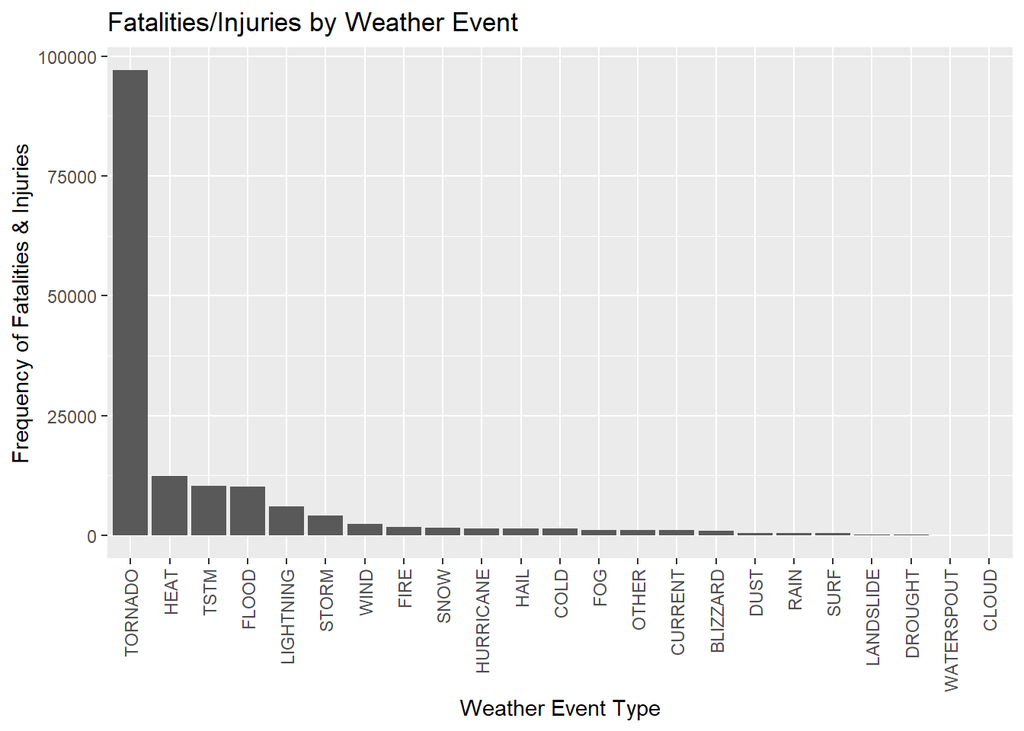

```r
# Calculate sum of FATALITIES & INJURIES as HEALTHHARM
data1 <- data %>% select(EVTYPE2, FATALITIES, INJURIES) %>%
    mutate(HEALTHHARM = FATALITIES + INJURIES) %>%
    dplyr::group_by(EVTYPE2) %>%
    dplyr::summarize(FATALITIES = sum(FATALITIES), INJURIES = sum(INJURIES),
    HEALTHHARM = sum(HEALTHHARM)) %>% arrange(desc(HEALTHHARM))

# Plot the Pareto Chart of HEALTHHARM by EVTYPE2
ggplot(data1, aes(x = reorder(EVTYPE2, -HEALTHHARM), y = HEALTHHARM)) +
  geom_bar(stat="identity") +
  theme(axis.text.x = element_text(angle = 90, vjust = 0.5, hjust=1)) +
  labs(x = "Weather Event Type", y = "Frequency of Fatalities & Injuries") +
  labs(title = "Fatalities/Injuries by Weather Event")
```

### Q2. **Flood** is the weather event that causes the damage on property & crop in terms of dollar value

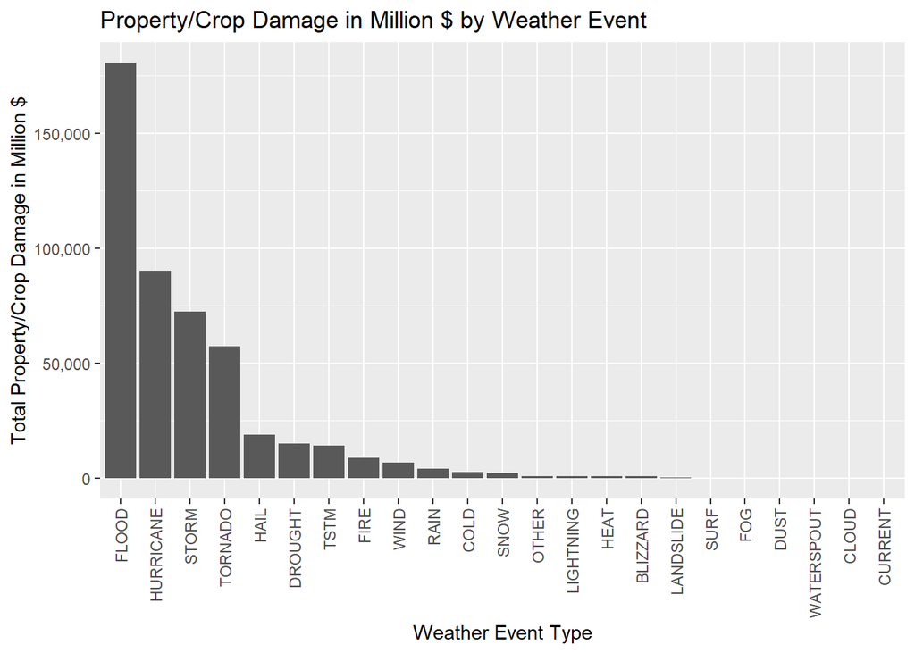

```r
# Calculate sum of PROPDMGTOTAL & CROPDMGTOTAL as DMGTOTAL
data2 <- data %>% select(EVTYPE2, PROPDMGTOTAL, CROPDMGTOTAL) %>%
    mutate(DMGTOTAL = PROPDMGTOTAL + CROPDMGTOTAL) %>%
    dplyr::group_by(EVTYPE2) %>%
    dplyr::summarize(PROPDMGTOTAL = sum(PROPDMGTOTAL), CROPDMGTOTAL = sum(CROPDMGTOTAL),
    DMGTOTAL = sum(DMGTOTAL)) %>% arrange(desc(DMGTOTAL))

# Plot the Pareto Chart of DMGTOTAL by EVTYPE2
ggplot(data2, aes(x = reorder(EVTYPE2, -DMGTOTAL), y = DMGTOTAL/10^6)) +
  geom_bar(stat="identity") +
  theme(axis.text.x = element_text(angle = 90, vjust = 0.5, hjust=1)) +
  labs(x = "Weather Event Type", y = "Total Property/Crop Damage in Million $") +
  labs(title = "Property/Crop Damage in Million $ by Weather Event") +
  scale_y_continuous(labels = comma)
```